# Question_2

Jay

7 October 2019

# Finding 1

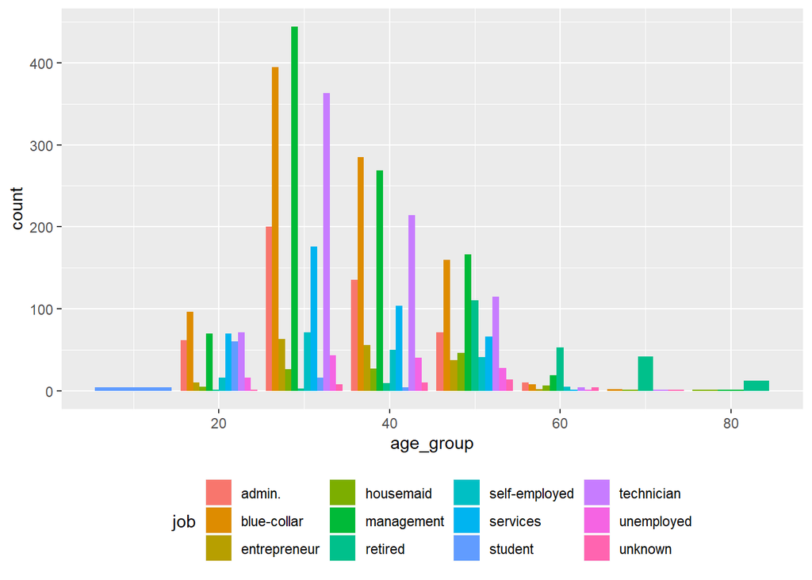

```r
bank <- mutate(bank, age_group = floor(age/10)*10)
bank %>%
    ggplot(aes(x = age_group, fill = job)) + geom_bar(position = "dodge") +
    theme(legend.position = "bottom")
```

Most of the people in this dataset is in their 30s and almost for every job the age group of the workers culminate at 30s. For people from 30 to 50, most of them make living as managers, blue-collar workers, and technicians.

# Finding 2

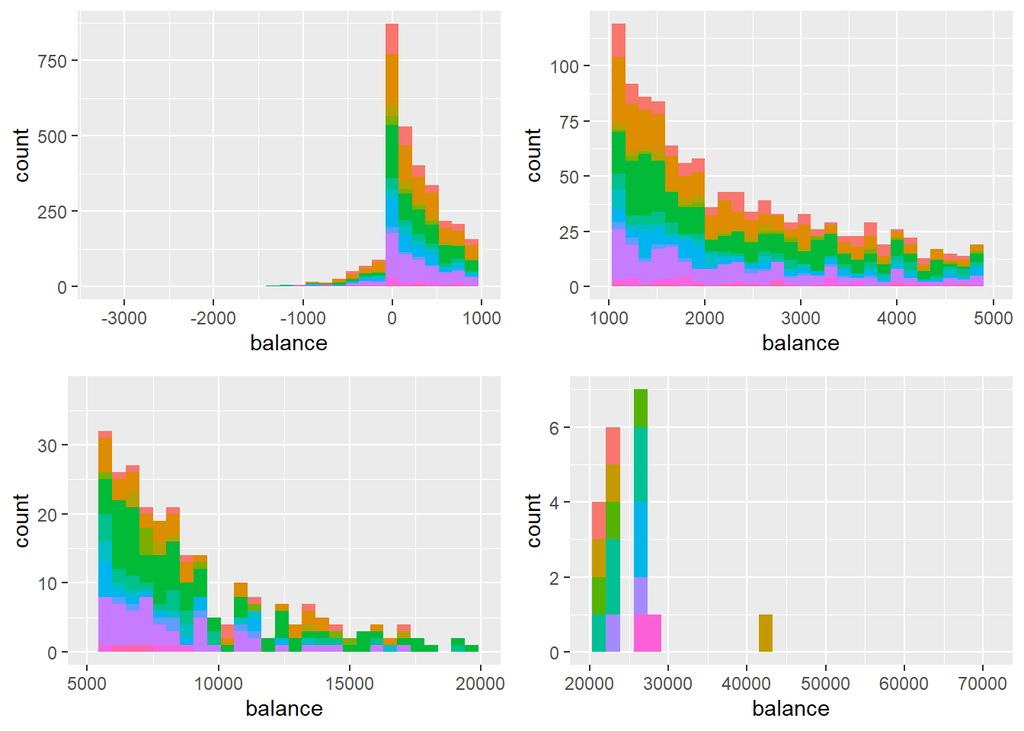

```r
g1 <- ggplot(bank, aes(balance, fill = job)) +
    geom_histogram() +
    xlim(min(bank$balance), 1000) +
    guides(fill = "none")
g2 <- ggplot(bank, aes(balance, fill = job)) +
    geom_histogram() +
    xlim(1000, 5000) +
    guides(fill = "none")
g3 <- ggplot(bank, aes(balance, fill = job)) +
    geom_histogram() +
    xlim(5000, 20000) +
    guides(fill = "none")
g4 <- ggplot(bank, aes(balance, fill = job)) +
    geom_histogram() +
    xlim(20000, max(bank$balance)) +
    guides(fill = "none")
grid.arrange(g1, g2, g3, g4, ncol = 2)
```

This plot demestrate the account balance and different colors represents different jobs. Do note that the y axis has different scales in these four plots.

- People with balance smaller than 1000 account the biggest proportion in the dataset.
- It seems people with the same jobs, like managers, blue-collar workers, services and technicians do have different account balances ranging from 0 to about 15000.
- Peopel with account balance larger than 15000 are very few and their jobs do differ.
- The wealthiest guy is an entrepreneur

# Finding 3

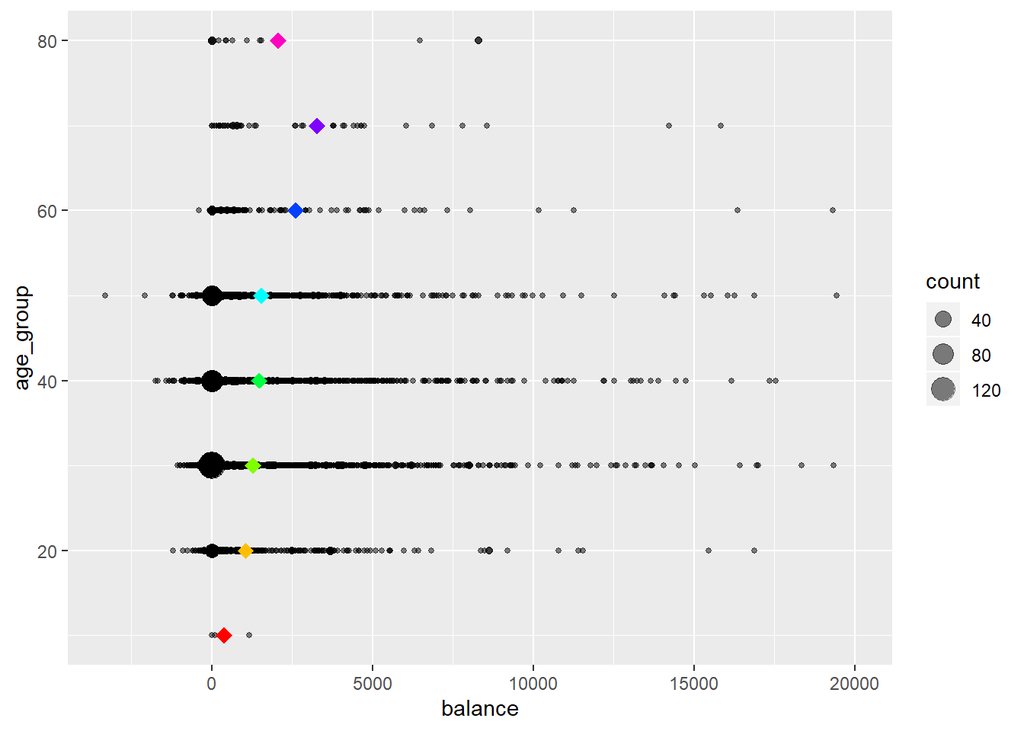

```r
ggplot(data = full_join(bank, bank %>% group_by(age_group, balance) %>% summarise(count = n())),
       aes(age_group, balance, size = count)) +
    geom_point(alpha = 0.5) +
    coord_flip() +
    ylim(min(bank$balance), 20000) +
    geom_point(data = group_by(bank, age_group) %>% summarise(ave_balance = mean(balance)),
               aes(x = age_group, y = ave_balance), inherit.aes = F, col = rainbow(8), size = 3.5, shape = 18)
```

The colored dots are the average balance for different age group. For almost every age group, a lot of people have balance around 0. As age becomes greater, the average balance also increases and people after their 60s have the highest balance.

# Finding 4

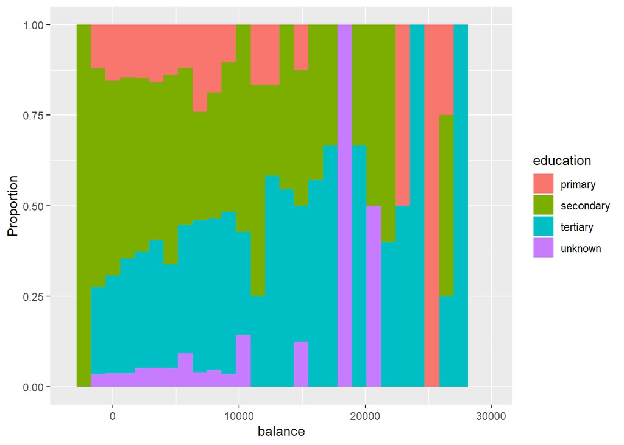

```r
ggplot(bank, aes(balance, fill = education)) +
    geom_histogram(position = "fill") +
    xlim(min(bank$balance), 30000)+
    labs(y = "Proportion")
```

For people with lower balance, especially around 0, most of them have received secondary education. As the balance becomes larger, the proportion of people with tertiary education also becomes greater, which may indicate that obtaining tertiary education could potentially increase your wealth.